# 情報科学3

クラスタリング

矢内 勇生

2021-11-05（改訂：2021-11-09）

## 準備

必要なパッケージを読み込む。

```r
pacman::p_load(tidyverse,
               patchwork,
               GGally,
               clustrd)
```

## $K$平均法の仕組み

### データの準備

```r
df1 <- tibble(
  x1 = c(1, 1, 2, 3, 6, 7, 7, 9, 3, 3),
  x2 = c(4, 8, 7, 8, 4, 2, 3, 4, 2, 1)
)
```

散布図を作る。

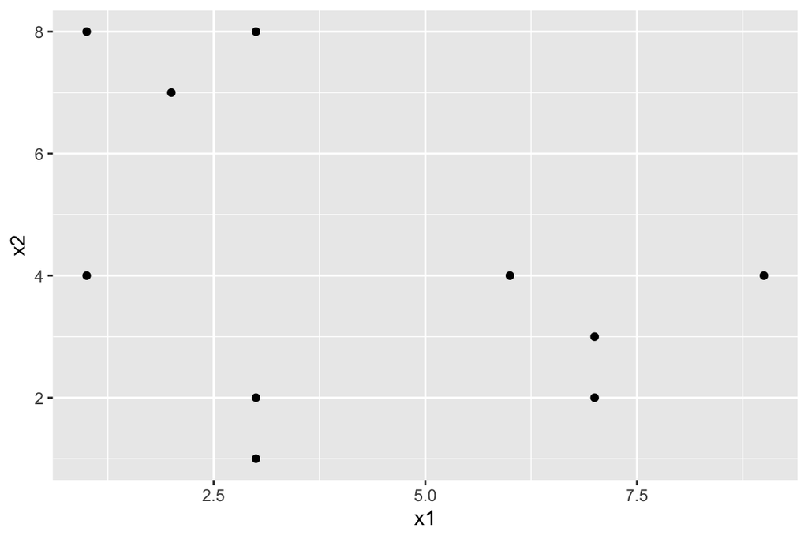

```r
p <- ggplot(df1, aes(x = x1, y = x2)) +
  geom_point()
plot(p)
```

### $K$平均法

`df1` に含まれる観測点を、$k=3$の$K$平均法で3つのクラスタに分けてみよう。

**(1)**

まず、ランダムに3点を選び、それらを別のクラスに分類する。

```r
set.seed(2021-11-06)
df2 <- df1 %>%
  mutate(cluster = sample(c(1:3, rep(NA, n() - 3)), size = n()),
         cluster = factor(cluster))
```

選んだ3点を表示する。

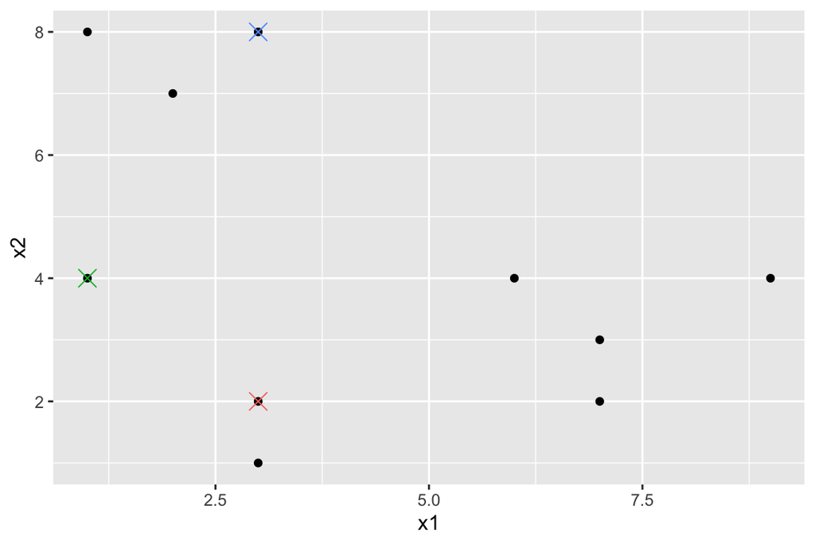

```r
p1 <- p +
  geom_point(data = filter(df2, !is.na(cluster)),
             aes(x = x1, y = x2, color = cluster),
             shape = 4, size = 4) +
  theme(legend.position = "none")
plot(p1)
```

3点までの距離を測り、最も近いグループに分類する。今回は、ユークリッド距離を利用する。 平面上でユークリッド距離を測る関数を作る。

```r
dist_euc <- function(x, y, a, b) {
  # (x, y) と (a, b) のユークリッド距離
  sqrt((x - a)^2 + (y - b)^2)
}
```

クラスタ1〜3の座標を取り出す。

```r
# クラスタ1
x1_c1 <- df2 %>% filter(cluster == 1) %>% pull(x1)
x2_c1 <- df2 %>% filter(cluster == 1) %>% pull(x2)

# クラスタ2
x1_c2 <- df2 %>% filter(cluster == 2) %>% pull(x1)
x2_c2 <- df2 %>% filter(cluster == 2) %>% pull(x2)

# クラスタ3
x1_c3 <- df2 %>% filter(cluster == 3) %>% pull(x1)
x2_c3 <- df2 %>% filter(cluster == 3) %>% pull(x2)
```

各点とそれぞれのクラスタの「中心」との距離を測る。

```r
df2 <- df2 %>%
  mutate(dist_1 = dist_euc(x1, x2, x1_c1, x2_c1),
         dist_2 = dist_euc(x1, x2, x1_c2, x2_c2),
         dist_3 = dist_euc(x1, x2, x1_c3, x2_c3))
```

各点を、最も距離が短いクラスに分類する。

```r
df2 <- df2 %>%
  mutate(cluster = case_when(
    dist_1 <= dist_2 & dist_1 < dist_3  ~ 1,
    dist_2 <  dist_1 & dist_2 <= dist_3 ~ 2,
    TRUE                                ~ 3))
```

途中経過を可視化する。

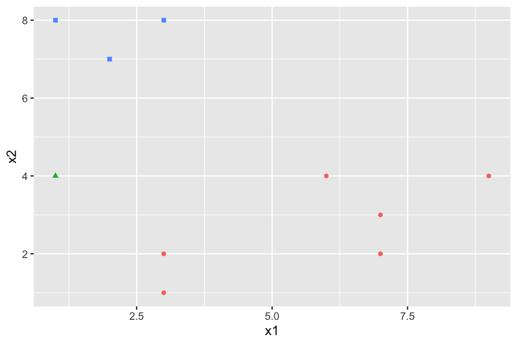

```r
p2 <- ggplot(df2, aes(x = x1, y = x2,
                      color = as.factor(cluster),
                      shape = as.factor(cluster))) +
  geom_point() +
  theme(legend.position = "none")
plot(p2)
```

**(2)**

ここまでの分類結果から、各クラスタの重心の座標を求める。

```r
# クラスタ1
x1_c1 <- df2 %>%
  filter(cluster == 1) %>%
  pull(x1) %>%
  mean()
x2_c1 <- df2 %>%
  filter(cluster == 1) %>%
  pull(x2) %>%
  mean()

# クラスタ2
x1_c2 <- df2 %>%
  filter(cluster == 2) %>%
  pull(x1) %>%
  mean()
x2_c2 <- df2 %>%
  filter(cluster == 2) %>%
  pull(x2) %>%
  mean()

# クラスタ3
x1_c3 <- df2 %>%
  filter(cluster == 3) %>%
  pull(x1) %>%
  mean()
x2_c3 <- df2 %>%
  filter(cluster == 3) %>%
  pull(x2) %>%
  mean()

## tibble にまとめる
df2_center <- tibble(
  x1 = c(x1_c1, x1_c2, x1_c3),
  x2 = c(x2_c1, x2_c2, x2_c3),
  cluster = factor(1:3))
```

各クラスタの重心を図に加える。

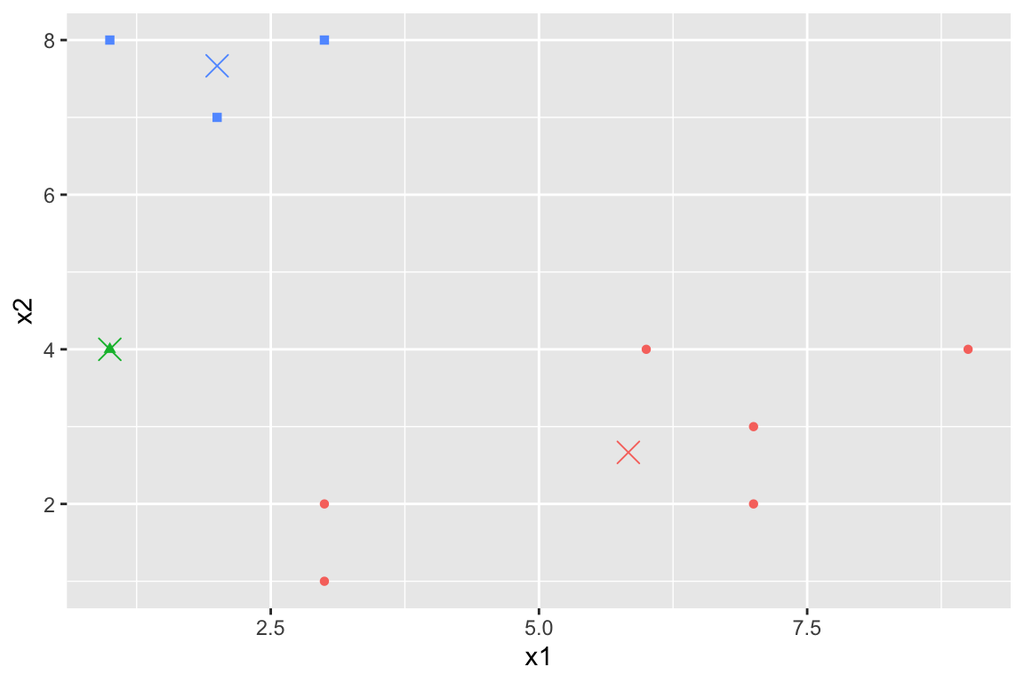

```r
p2_c <- p2 +
  geom_point(data = df2_center,
             aes(x = x1, y = x2,
                 color = cluster,
                 shape = cluster),
             shape = 4, size = 4)
plot(p2_c)
```

各点とそれぞれのクラスタの重心との距離を測る。

```r
df3 <- df2 %>%
  mutate(dist_1 = dist_euc(x1, x2, x1_c1, x2_c1),
         dist_2 = dist_euc(x1, x2, x1_c2, x2_c2),
         dist_3 = dist_euc(x1, x2, x1_c3, x2_c3))
```

各点を、最も距離が短いクラスに分類する。

```r
df3 <- df3 %>%
  mutate(cluster = case_when(
    dist_1 <= dist_2 & dist_1 < dist_3  ~ 1,
    dist_2 <  dist_1 & dist_2 <= dist_3 ~ 2,
    TRUE                                ~ 3))
```

途中経過を可視化する。

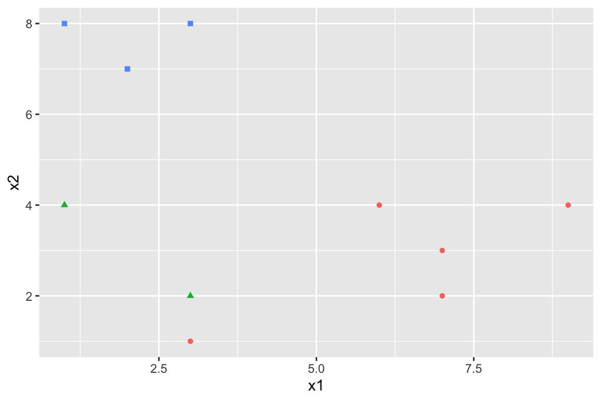

```r
p3 <- ggplot(df3, aes(x = x1, y = x2,
                      color = as.factor(cluster),
                      shape = as.factor(cluster))) +
  geom_point() +
  theme(legend.position = "none")
plot(p3)
```

**(3)**

ここまでの分類結果から、各クラスタの重心の座標を求める。

```r
# クラスタ1
x1_c1 <- df3 %>%
  filter(cluster == 1) %>%
  pull(x1) %>%
  mean()
x2_c1 <- df3 %>%
  filter(cluster == 1) %>%
  pull(x2) %>%
  mean()

# クラスタ2
x1_c2 <- df3 %>%
  filter(cluster == 2) %>%
  pull(x1) %>%
  mean()
x2_c2 <- df3 %>%
  filter(cluster == 2) %>%
  pull(x2) %>%
  mean()

# クラスタ3
x1_c3 <- df3 %>%
  filter(cluster == 3) %>%
  pull(x1) %>%
  mean()
x2_c3 <- df3 %>%
  filter(cluster == 3) %>%
  pull(x2) %>%
  mean()

## tibble にまとめる
df3_center <- tibble(
  x1 = c(x1_c1, x1_c2, x1_c3),
  x2 = c(x2_c1, x2_c2, x2_c3),
  cluster = factor(1:3))
```

各クラスタの重心を図に加える。

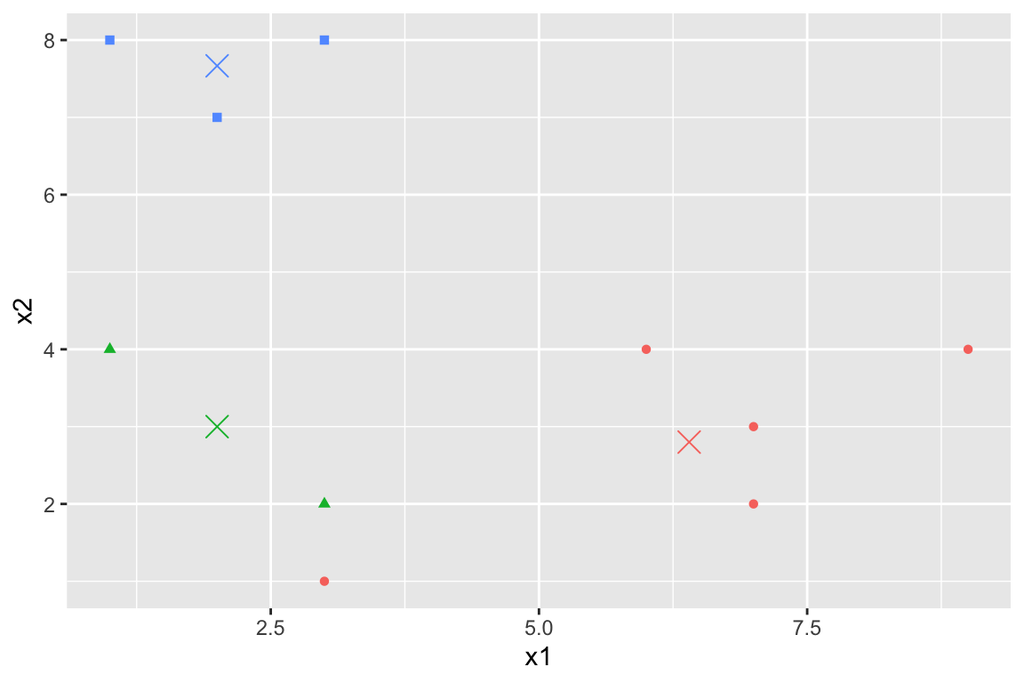

```r
p3_c <- p3 +
  geom_point(data = df3_center,
             aes(x = x1,
                 y = x2,
                 color = cluster,
                 shape = cluster),
             shape = 4, size = 4)
plot(p3_c)
```

各点とそれぞれのクラスタの重心との距離を測る。

```r
df4 <- df3 %>%
  mutate(dist_1 = dist_euc(x1, x2, x1_c1, x2_c1),
         dist_2 = dist_euc(x1, x2, x1_c2, x2_c2),
         dist_3 = dist_euc(x1, x2, x1_c3, x2_c3))
```

各点を、最も距離が短いクラスに分類する。

```r
df4 <- df4 %>%
  mutate(cluster = case_when(
    dist_1 <= dist_2 & dist_1 < dist_3  ~ 1,
    dist_2 <  dist_1 & dist_2 <= dist_3 ~ 2,
    TRUE                                ~ 3))
```

途中経過を可視化する。

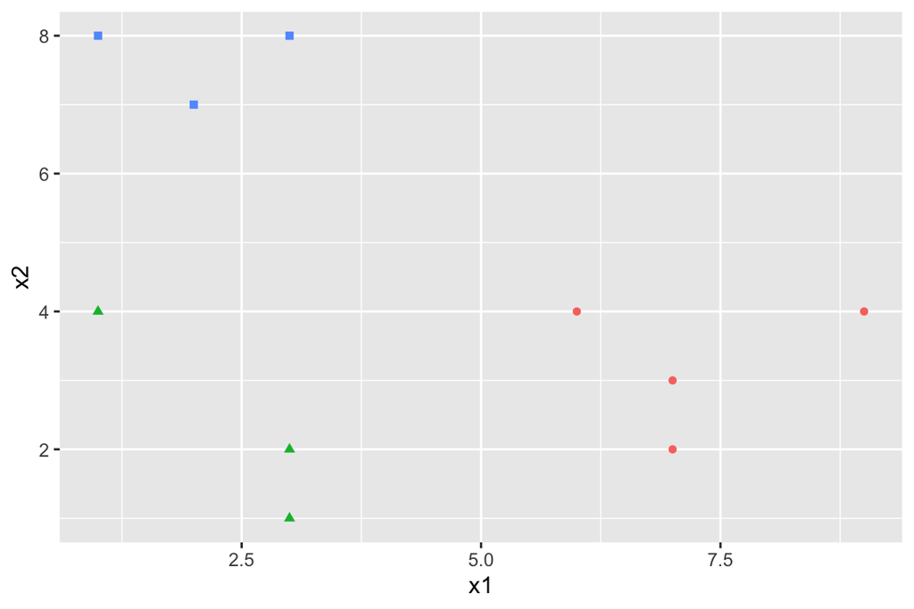

```r
p4 <- ggplot(df4, aes(x = x1,
                      y = x2,
                      color = as.factor(cluster),
                      shape = as.factor(cluster))) +
  geom_point() +
  theme(legend.position = "none")
plot(p4)
```

**(4)**

ここまでの分類結果から、各クラスタの重心の座標を求める。

```r
# クラスタ1
x1_c1 <- df4 %>%
  filter(cluster == 1) %>%
  pull(x1) %>%
  mean()
x2_c1 <- df4 %>%
  filter(cluster == 1) %>%
  pull(x2) %>%
  mean()

# クラスタ2
x1_c2 <- df4 %>%
  filter(cluster == 2) %>%
  pull(x1) %>%
  mean()
x2_c2 <- df4 %>%
  filter(cluster == 2) %>%
  pull(x2) %>%
  mean()

# クラスタ3
x1_c3 <- df4 %>%
  filter(cluster == 3) %>%
  pull(x1) %>%
  mean()
x2_c3 <- df4 %>%
  filter(cluster == 3) %>%
  pull(x2) %>%
  mean()

## tibble にまとめる
df4_center <- tibble(
  x1 = c(x1_c1, x1_c2, x1_c3),
  x2 = c(x2_c1, x2_c2, x2_c3),
  cluster = factor(1:3))
```

各クラスタの重心を図に加える。

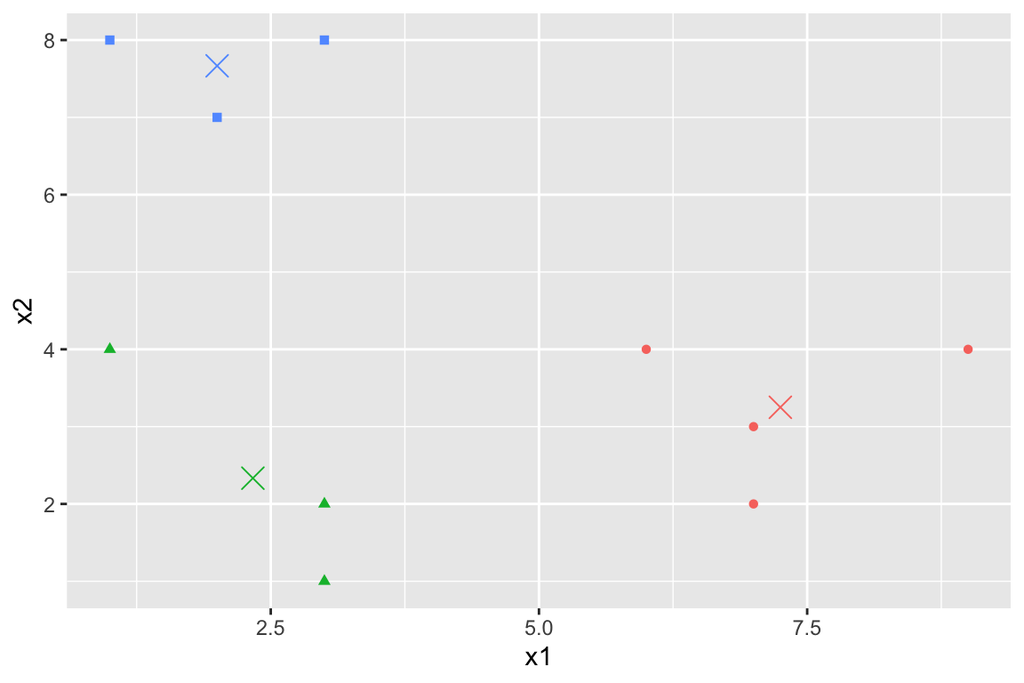

```r
p4_c <- p4 +
  geom_point(data = df4_center,
             aes(x = x1,
                 y = x2,
                 color = cluster,
                 shape = cluster),
             shape = 4, size = 4)
plot(p4_c)
```

各点とそれぞれのクラスタの重心との距離を測る。

```r
df5 <- df4 %>%
  mutate(dist_1 = dist_euc(x1, x2, x1_c1, x2_c1),
         dist_2 = dist_euc(x1, x2, x1_c2, x2_c2),
         dist_3 = dist_euc(x1, x2, x1_c3, x2_c3))
```

各点を、最も距離が短いクラスに分類する。

```r
df5 <- df5 %>%
  mutate(cluster = case_when(
    dist_1 <= dist_2 & dist_1 < dist_3  ~ 1,
    dist_2 <  dist_1 & dist_2 <= dist_3 ~ 2,
    TRUE                                ~ 3))
```

途中経過を可視化する。

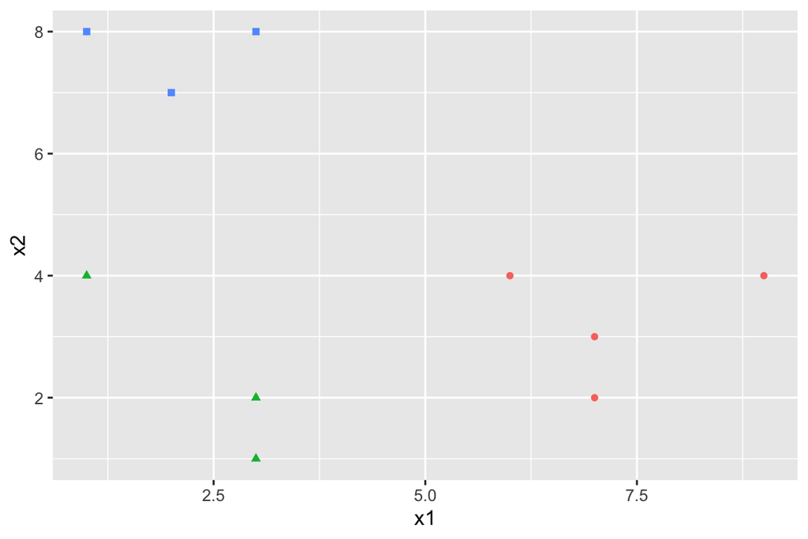

```r
p5 <- ggplot(df5, aes(x = x1,
                      y = x2,
                      color = as.factor(cluster),
                      shape = as.factor(cluster))) +
  geom_point() +
  theme(legend.position = "none")
plot(p5)
```

`p4` と `p5` を比べてみよう。

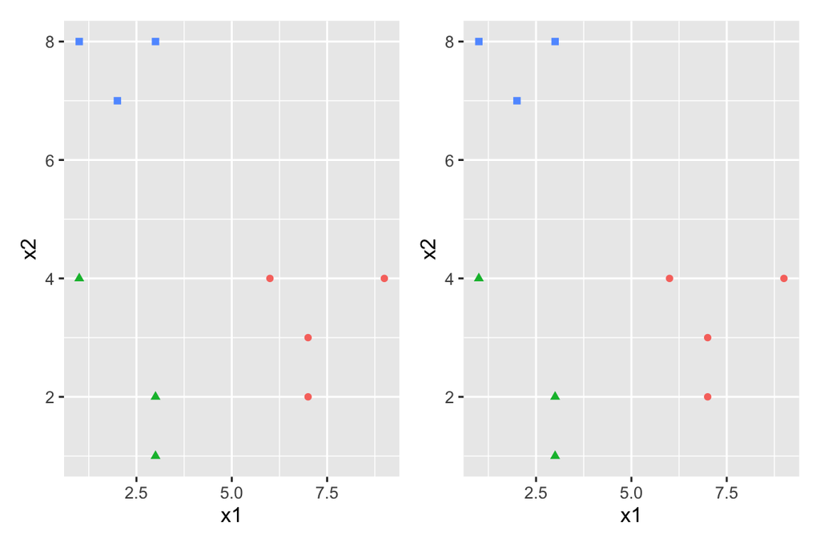

```r
plot(p4 | p5)
```

グルーピングに変化がないことがわかる。よって、ここでクラスタリングを終了する。

## Rによるクラスタリングの実行手順

**clustrd**パッケージに含まれる `macro` データを使って実習を行う。

```r
data(macro)
glimpse(macro)
```

```
## Rows: 20
## Columns: 6
## $ GDP <dbl> 4.8, 3.2, 3.9, 2.3, 3.6, 4.1, 4.1, 2.9, 3.2, 2.3, 2.8, 1.1, 1.4, 1…
## $ LI  <dbl> 8.4, 2.5, -1.0, 0.7, 2.5, 1.1, 1.4, 1.6, 0.6, 5.6, -7.5, 0.6, -0.1…
## $ UR  <dbl> 8.1, 8.4, 11.8, 11.7, 19.0, 8.9, 4.5, 4.2, 10.3, 3.2, 4.9, 4.7, 9.…
## $ IR  <dbl> 5.32, 5.02, 3.60, 3.69, 4.83, 4.20, 5.59, 3.69, 11.70, 20.99, 4.84…
## $ TB  <dbl> 0.7, 1.6, 8.8, 3.9, 1.2, 7.0, -1.4, 7.0, -8.3, 0.0, -8.7, -0.6, 4.…
## $ NNS <dbl> 4.7, 5.2, 7.7, 7.3, 9.6, 4.0, 7.0, 15.8, 8.0, 12.7, 14.0, 9.4, 12.…
```

このデータセットは、GDPをはじめとする6つの経済指標を20か国について記録している。データに含まれる国は、`row.names()` で確認できる。

```r
row.names(macro)
```

```
##  [1] "Australia"   "Canada"      "Finland"     "France"      "Spain"
##  [6] "Sweden"      "USA"         "Netherlands" "Greece"      "Mexico"
## [11] "Portugal"    "Austria"     "Belgium"     "Denmark"     "Germany"
## [16] "Italy"       "Japan"       "Norway"      "Switzerland" "UK"
```

### 階層的クラスタリング

階層的クラスタリング (hierarchical clustering) は`hclust()` で実行できる。 `method` 引数で、グループ間の距離の測り方を指定する。選択肢は、

- `"single"`：単リンク法（最短距離法）
- `"complete"`：完全リンク法（最長距離法）
- `"average"`：群平均法
- `"centroid"`：重心法
- `"ward.D2"`：ウォード法

である。

まず、単リンク法でクラスタリングを実行してみよう。`hclust()` の第1引数は、`dist()` の結果として出力される非類似度行列（dissimilarity matrix）なので、`dist()` の結果を保存してから実行しよう。

```r
macro_dist <- dist(macro)
c_single <- hclust(macro_dist, method = "single")
```

この結果を `plot()` すると、樹形図（dendrogram, デンドログラム）が表示される。

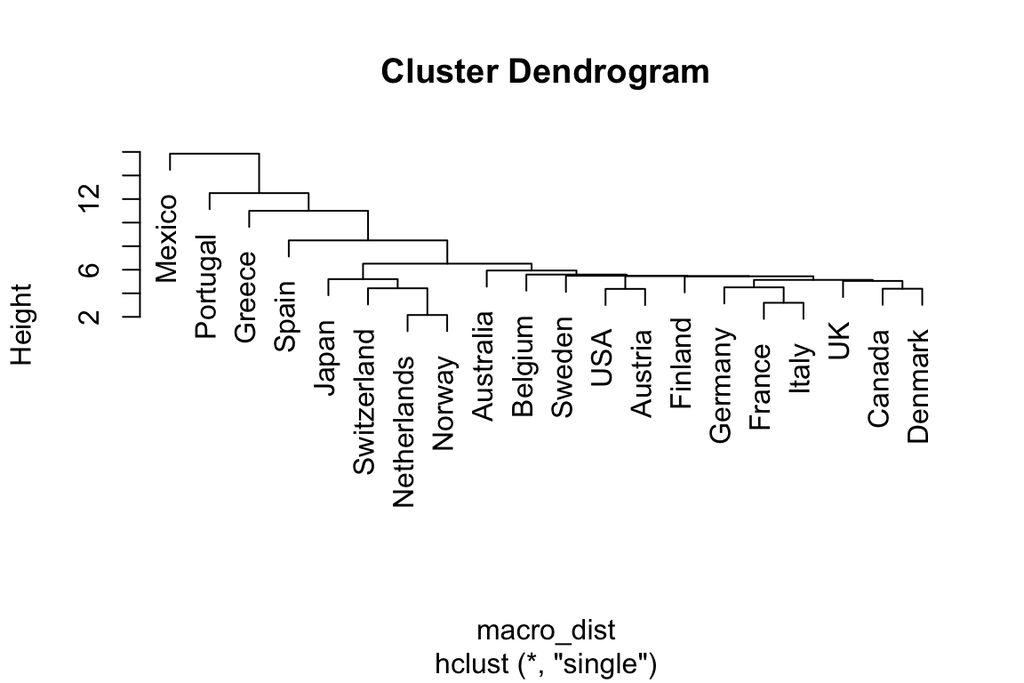

```r
plot(c_single)
```

各ステップでのグループ間の距離は、樹形図の枝の高さで示されている。 この高さは、次のようにして確認できる。

```r
c_single$height
```

```
##  [1]  2.158333  3.195638  4.375214  4.389032  4.426839  4.505830  5.050980
##  [8]  5.138959  5.206726  5.444089  5.458470  5.490902  5.591386  5.934172
## [15]  6.516134  8.491148 11.001459 12.502400 15.850050
```

この結果を元に、クラスタの数を$k$に指定するには`cutree()`を使う。$k=3$にしてみよう。

```r
cutree(c_single, k = 3)
```

```
##   Australia      Canada     Finland      France       Spain      Sweden
##           1           1           1           1           1           1
##         USA Netherlands      Greece      Mexico    Portugal     Austria
##           1           1           1           2           3           1
##     Belgium     Denmark     Germany       Italy       Japan      Norway
##           1           1           1           1           1           1
## Switzerland          UK
##           1           1
```

メキシコとポルトガルがそれぞれ単独でグループを作り、残りの18か国が1つのグループに分けられれた。

次に、完全リンク法でクラスタリングを行ってみよう。

```r
c_complete <- hclust(macro_dist, method = "complete")
```

樹形図を示す。

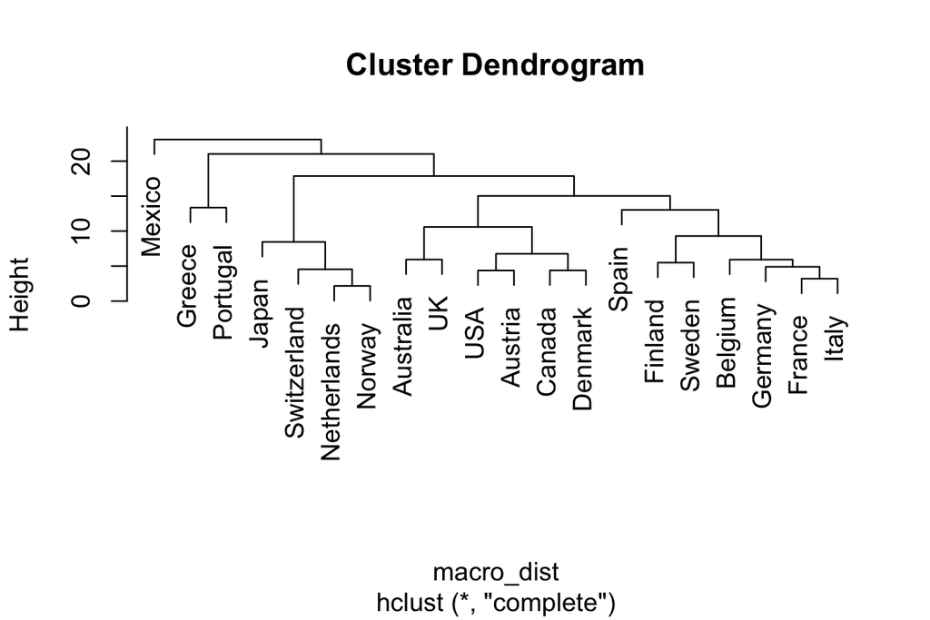

```r
plot(c_complete)
```

$k=3$でクラスタに分ける。

```r
cutree(c_complete, k = 3)
```

```
##   Australia      Canada     Finland      France       Spain      Sweden
##           1           1           1           1           1           1
##         USA Netherlands      Greece      Mexico    Portugal     Austria
##           1           1           2           3           2           1
##     Belgium     Denmark     Germany       Italy       Japan      Norway
##           1           1           1           1           1           1
## Switzerland          UK
##           1           1
```

メキシコは相変わらず単独でクラスタを構成しているが、ポルトガルはギリシャと同じクラスタになった。残りの17か国は同じクラスタに分類されている。

**実習課題**

- 距離の測り方を変えてクラスタリングを実行し、距離の測り方によって結果がどのように異なるか考察しなさい。
- $k$の値を4や5にすると、距離の測り方による違いはどう変化するだろうか。

### 非階層的クラスタリング：$K$平均法

$K$平均法は、`kmeans()` で実行できる。クラスタの数は `centers` 引数で指定する。 $K=3$で分類してみよう。

```r
set.seed(2021-11-07)
c_k3 <- kmeans(macro, centers = 3)
```

結果を確認しよう。

```r
c_k3$cluster
```

```
##   Australia      Canada     Finland      France       Spain      Sweden
##           2           2           2           2           2           2
##         USA Netherlands      Greece      Mexico    Portugal     Austria
##           3           1           3           3           3           3
##     Belgium     Denmark     Germany       Italy       Japan      Norway
##           2           2           2           2           1           1
## Switzerland          UK
##           1           3
```

階層的クラスタリングとは異なる結果が得られている。

`kmeans()` 関数は、最初のステップにおけるグループの中心をランダムに選ぶ。 `nstart` 引数を1より大きい値に設定すると、複数の初期値をランダムに選び、最もよい結果のみを返す。 試しに、`nstart = 50` にしてみよう。

```r
c_k3b <- kmeans(macro, centers = 3, nstart = 50)
```

結果を確認しよう。

```r
c_k3b$cluster
```

```
##   Australia      Canada     Finland      France       Spain      Sweden
##           2           2           2           2           2           2
##         USA Netherlands      Greece      Mexico    Portugal     Austria
##           2           3           1           1           1           2
##     Belgium     Denmark     Germany       Italy       Japan      Norway
##           3           2           2           2           3           3
## Switzerland          UK
##           3           2
```

先ほどとは異なる結果が得られた。ただし、グループのラベルの付け方が異なる。（注意：日本やノルウェーなどを含むグループのラベルが1から3に変わっているが、ラベルの変更は結果の違いとは言えない。）

各グループのばらつき具合は、クラスタ内総平方和で測られる。先程の結果と比べてみよう。

```r
rbind(c_k3$tot.withinss,
      c_k3b$tot.withinss)
```

```
##          [,1]
## [1,] 895.9534
## [2,] 863.4262
```

クラスタ内総平方和が小さくなっており、先程よりも各グループが似た者同士の集まりになっていると考えられる。

結果を可視化するために、元のデータにクラスタリングの結果を加えた tibble を作る。

```r
df_k3b <- macro %>%
  mutate(cluster = factor(c_k3b$cluster))
```

**GGally**パッケージの `ggpairs()` で散布図行列を作る。

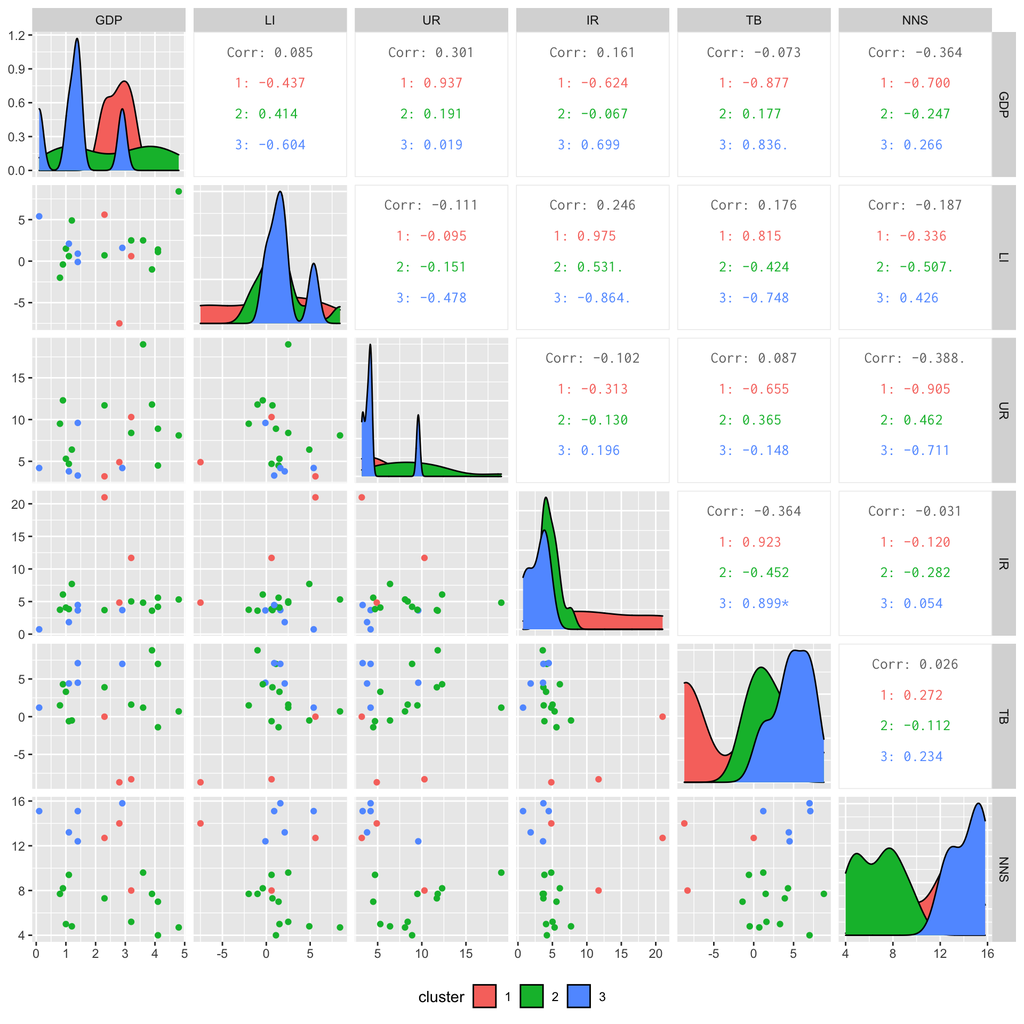

```r
ggpairs(df_k3b,
        columns = 1:6,
        aes(color = cluster),
        legend = 1) +
  theme(legend.position = "bottom")
```